# Notebook 04: Perform EDA

Author

Shirshak Aryal

Published

July 3, 2026

Perform **Exploratory Data Analysis (EDA) measures** on the **filtered** **`unstranded` raw counts matrix**. The primary purpose of EDA in this project is to **explore the primary basis of variance between the samples**.

The EDA steps will be performed with the **top 500 Highly Variable Genes (HVGs) only,** since these are the only genes that likely have **highly fluctuating expression levels among samples**. The **rest of the genes** are composed of housekeeping genes, ribosomal genes, etc., that have a relatively **consistent expression** throughout all samples, regardless of subtype.

The EDA steps are hence as follows:

- **Setup**: Identify and select the **top 500 HVGs**.
- **PC variance decomposition**:
  - **HVG PCA plot**: Perform PCA on the HVGs to explore the **top basis of variance** among samples.
  - **Scree plot**: Plot **variance explained per PC** and identify the **elbow**, i.e. the point where the curve transitions from steep decline to flat plateau, indicating **diminishing returns per additional PC.**
  - **Pathway identification**: For **each PC up to the elbow**, identify the **top contributing genes** and perform quick GO enrichment to identify the **main biological processes** driving variance among samples.
- **Sample correlation heatmap**: Heatmap based on gene expression correlation between all samples, **annotated by subtype** to assess if samples **cluster by subtype**.

## 1. Import Libraries

```r
library(tidyverse)        # data manipulation and visualisation
library(matrixStats)      # row and column-wise statistical operations on matrices
library(patchwork)        # combine multiple ggplot2 plots into one canvas
library(pheatmap)         # colorful heatmaps
library(enrichplot)       # visualisation of enrichment results
library(clusterProfiler)  # gene set enrichment and pathway analysis
library(org.Hs.eg.db)     # human gene annotation database

cat("\nLibraries loaded successfully\n")
```

```
Libraries loaded successfully
```

```r
cat("tidyverse version:       ", as.character(packageVersion("tidyverse")), "\n")
```

```
tidyverse version:        2.0.0
```

```r
cat("matrixStats version:     ", as.character(packageVersion("matrixStats")), "\n")
```

```
matrixStats version:      1.5.0
```

```r
cat("patchwork version:       ", as.character(packageVersion("patchwork")), "\n")
```

```
patchwork version:        1.3.2
```

```r
cat("pheatmap version:        ", as.character(packageVersion("pheatmap")), "\n")
```

```
pheatmap version:         1.0.13
```

```r
cat("enrichplot version:      ", as.character(packageVersion("enrichplot")), "\n")
```

```
enrichplot version:       1.30.4
```

```r
cat("clusterProfiler version: ", as.character(packageVersion("clusterProfiler")), "\n")
```

```
clusterProfiler version:  4.18.4
```

```r
cat("org.Hs.eg.db version:    ", as.character(packageVersion("org.Hs.eg.db")), "\n")
```

```
org.Hs.eg.db version:     3.22.0
```

## 2. Load Data

### 2.1. Load Filtered Counts Matrix

```r
filtered_counts_matrix <- readRDS("../01_data/02_processed/04_filtered_counts_matrix.rds")

cat("Filtered counts matrix loaded:", nrow(filtered_counts_matrix), "genes x", ncol(filtered_counts_matrix), "samples\n\n")
```

```
Filtered counts matrix loaded: 16164 genes x 180 samples
```

```r
filtered_counts_matrix[1:3, 1:3]
```

```
                   TCGA-06-0166-01A-01R-A96R-41 TCGA-06-5859-01A-01R-1849-01
ENSG00000000003.15                         2149                         6236
ENSG00000000005.6                             7                          124
ENSG00000000419.13                          945                         1491
                   TCGA-06-5859-01A-01R-A96S-41
ENSG00000000003.15                         5577
ENSG00000000005.6                           136
ENSG00000000419.13                         1251
```

### 2.2. Load Filtered Tumor Subtype Information

```r
tumor_subtype_info <- readRDS("../01_data/02_processed/05_filtered_tumor_subtype_info.rds")

cat("Filtered tumor subtype info loaded:", nrow(tumor_subtype_info), "samples\n")
```

```
Filtered tumor subtype info loaded: 180 samples
```

```r
tumor_subtype_info %>%
  as.data.frame() %>%
  dplyr::select(paper_Transcriptome.Subtype) %>%
  head(5) %>%
  knitr::kable()
```

|  | paper_Transcriptome.Subtype |
| --- | --- |
| TCGA-06-0166-01A-01R-A96R-41 | PN |
| TCGA-06-5859-01A-01R-1849-01 | ME |
| TCGA-06-5859-01A-01R-A96S-41 | ME |
| TCGA-14-4157-01A-01R-A96U-41 | PN |
| TCGA-06-5416-01A-01R-1849-01 | PN |

### 2.3. Load Filtered Gene Metadata

```r
gene_metadata <- readRDS("../01_data/02_processed/06_filtered_gene_metadata.rds")
cat("Filtered gene metadata loaded:", nrow(gene_metadata), "genes\n")
```

```
Filtered gene metadata loaded: 16164 genes
```

```r
gene_metadata[1:5, 1:8] %>% as.data.frame() %>% knitr::kable()
```

|  | source | type | score | phase | gene_id | gene_type | gene_name | level |
| --- | --- | --- | --- | --- | --- | --- | --- | --- |
| ENSG00000000003.15 | HAVANA | gene | NA | NA | ENSG00000000003.15 | protein_coding | TSPAN6 | 2 |
| ENSG00000000005.6 | HAVANA | gene | NA | NA | ENSG00000000005.6 | protein_coding | TNMD | 2 |
| ENSG00000000419.13 | HAVANA | gene | NA | NA | ENSG00000000419.13 | protein_coding | DPM1 | 2 |
| ENSG00000000457.14 | HAVANA | gene | NA | NA | ENSG00000000457.14 | protein_coding | SCYL3 | 2 |
| ENSG00000000460.17 | HAVANA | gene | NA | NA | ENSG00000000460.17 | protein_coding | C1orf112 | 2 |

## 3. Perform EDA

### 3.1. Calculate HVGs

```r
# calculate per-gene variance across all samples (log1p transformed)
gene_vars    <- rowVars(log1p(filtered_counts_matrix))
names(gene_vars) <- rownames(filtered_counts_matrix)

# select top 500 genes by variance
top_hvg_ids  <- order(gene_vars, decreasing = TRUE)[1:500]
hvg_matrix   <- log1p(filtered_counts_matrix[top_hvg_ids, ])

cat("Total genes before HVG selection:", nrow(filtered_counts_matrix), "\n")
```

```
Total genes before HVG selection: 16164
```

```r
cat("HVGs selected:", nrow(hvg_matrix), "\n")
```

```
HVGs selected: 500
```

```r
cat("Top 5 HVG Ensembl IDs:\n")
```

```
Top 5 HVG Ensembl IDs:
```

```r
print(rownames(hvg_matrix)[1:5])
```

```
[1] "ENSG00000184357.5"  "ENSG00000277775.2"  "ENSG00000129824.16"
[4] "ENSG00000276410.4"  "ENSG00000286522.2"
```

### 3.2. Decompose Principal Component Variances

#### 3.2.1. Create HVG PCA Plot

##### 3.2.1.1. Perform PCA On HVGs

```r
pca_result <- prcomp(t(hvg_matrix), scale. = TRUE)

cat("PCA completed\n")
```

```
PCA completed
```

```r
cat("Samples (rows):", nrow(pca_result$x), "\n")
```

```
Samples (rows): 180
```

```r
cat("PCs computed:  ", ncol(pca_result$x), "\n")
```

```
PCs computed:   180
```

##### 3.2.1.2. Plot PCA On HVGs

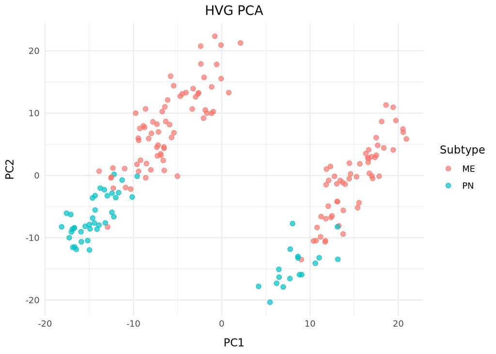

```r
pca_data    <- data.frame(
                 PC1     = pca_result$x[, 1],
                 PC2     = pca_result$x[, 2],
                 subtype = tumor_subtype_info$paper_Transcriptome.Subtype
               )
pca_mapping <- aes(x = PC1, y = PC2, colour = subtype)
pca_labels  <- labs(
                 title   = "HVG PCA",
                 x       = "PC1",
                 y       = "PC2",
                 colour  = "Subtype"
               )

pca_plot <- ggplot(pca_data, pca_mapping) +

            geom_point(alpha = 0.7, size = 2) +

            pca_labels +

            theme_minimal() +
            theme(
              plot.title = element_text(hjust = 0.5),                # center the title
              axis.title.x = element_text(margin = margin(t = 10)),  # add top margin to x-axis label
              axis.title.y = element_text(margin = margin(r = 10))   # add right margin to y-axis label
            )

pca_plot
```

#### 3.2.2. Create Scree Plot

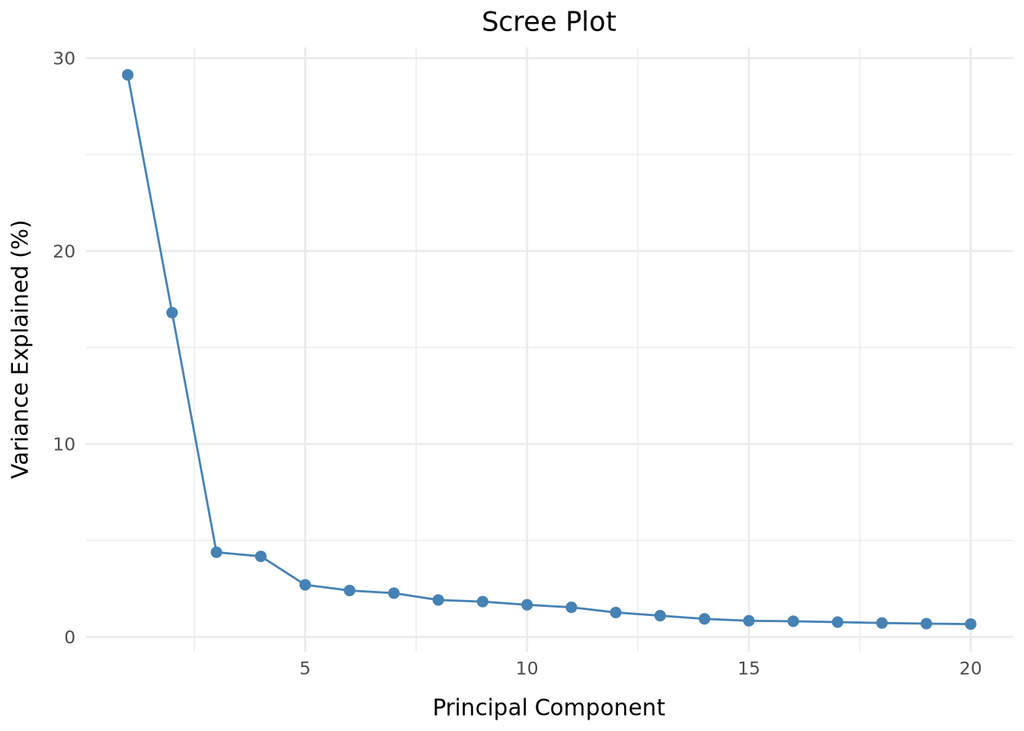

```r
# calculate variance explained per PC
var_explained <- pca_result$sdev^2 / sum(pca_result$sdev^2) * 100

# plot top 20 PCs only
scree_data    <- data.frame(
                   PC            = 1:20,
                   var_explained = var_explained[1:20]
                 )
scree_mapping <- aes(x = PC, y = var_explained)
scree_labels  <- labs(
                   title = "Scree Plot",
                   x     = "Principal Component",
                   y     = "Variance Explained (%)"
                 )

scree_plot <- ggplot(scree_data, scree_mapping) +

              geom_line(colour = "steelblue") +
              geom_point(colour = "steelblue", size = 2) +

              scree_labels +

              theme_minimal() +
              theme(
              plot.title = element_text(hjust = 0.5),                # center the title
              axis.title.x = element_text(margin = margin(t = 10)),  # add top margin to x-axis label
              axis.title.y = element_text(margin = margin(r = 10))   # add right margin to y-axis label
            )

scree_plot
```

#### 3.2.3. Extract PC Loadings

PC loadings here refer to the **top `n` genes that drive each principal component**. In this case, the **top 100 genes per PC** are selected, i.e. **20% of the total 500 HVGs.**

```r
# extract top 100 genes contributing to PC1, PC2, PC3
pc1_loadings <- sort(abs(pca_result$rotation[, 1]), decreasing = TRUE)[1:100]
pc2_loadings <- sort(abs(pca_result$rotation[, 2]), decreasing = TRUE)[1:100]
pc3_loadings <- sort(abs(pca_result$rotation[, 3]), decreasing = TRUE)[1:100]

cat("Top 10 genes driving PC1:\n")
```

```
Top 10 genes driving PC1:
```

```r
print(names(pc1_loadings)[1:10])
```

```
 [1] "ENSG00000174501.14" "ENSG00000278637.2"  "ENSG00000276966.2"
 [4] "ENSG00000135976.20" "ENSG00000184270.6"  "ENSG00000197061.5"
 [7] "ENSG00000168298.7"  "ENSG00000276410.4"  "ENSG00000286522.2"
[10] "ENSG00000127362.2"
```

```r
cat("\nTop 10 genes driving PC2:\n")
```

```
Top 10 genes driving PC2:
```

```r
print(names(pc2_loadings)[1:10])
```

```
 [1] "ENSG00000187135.7"  "ENSG00000166897.16" "ENSG00000170091.11"
 [4] "ENSG00000148798.11" "ENSG00000148123.15" "ENSG00000090932.11"
 [7] "ENSG00000105251.11" "ENSG00000177519.4"  "ENSG00000101204.18"
[10] "ENSG00000167654.18"
```

```r
cat("\nTop 10 genes driving PC3:\n")
```

```
Top 10 genes driving PC3:
```

```r
print(names(pc3_loadings)[1:10])
```

```
 [1] "ENSG00000022355.18" "ENSG00000104888.10" "ENSG00000164794.9"
 [4] "ENSG00000006116.4"  "ENSG00000154478.4"  "ENSG00000186297.12"
 [7] "ENSG00000113327.17" "ENSG00000187094.12" "ENSG00000163630.11"
[10] "ENSG00000166006.14"
```

```r
# strip version numbers from Ensembl IDs
cat("\nStripping version numbers from Ensembl IDs...\n\n")
```

```
Stripping version numbers from Ensembl IDs...
```

```r
pc1_ids <- gsub("\\..*", "", names(pc1_loadings))
pc2_ids <- gsub("\\..*", "", names(pc2_loadings))
pc3_ids <- gsub("\\..*", "", names(pc3_loadings))

cat("Converting Ensembl IDs to gene symbols...\n\n")
```

```
Converting Ensembl IDs to gene symbols...
```

```r
# convert Ensembl IDs to gene symbols
pc1_symbols <- bitr(pc1_ids, fromType = "ENSEMBL", toType = "SYMBOL", OrgDb = org.Hs.eg.db)
pc2_symbols <- bitr(pc2_ids, fromType = "ENSEMBL", toType = "SYMBOL", OrgDb = org.Hs.eg.db)
pc3_symbols <- bitr(pc3_ids, fromType = "ENSEMBL", toType = "SYMBOL", OrgDb = org.Hs.eg.db)
```

#### 3.2.4. Perform GO Enrichment On PC Loadings

##### 3.2.4.1. Perform GO:BP Enrichment

**Gene Ontology: Biological Process (GO:BP)** is a **pathway database maintained by the GO Consortium** that specifies pathways involved in specific **biological activities** such as glial cell differentiation, neural stem cell proliferation, apoptotic process, DNA repair, etc.

```r
# PC1 GO:BP enrichment
pc1_go <- enrichGO(
  gene          = pc1_ids,       # PC1 gene identifiers
  OrgDb         = org.Hs.eg.db,  # human gene annotation database
  keyType       = "ENSEMBL",     # gene identifiers are in Ensembl ID format
  ont           = "BP",          # test against the GO Biological Process (BP) database

  pAdjustMethod = "BH",          # correct for multiple testing using Benjamini-Hochberg FDR correction
  pvalueCutoff  = 0.05,          # only consider p-values < 0.05 as significant

  readable      = TRUE           # convert Ensembl IDs to gene symbols in the output
)



# PC2 GO:BP enrichment
pc2_go <- enrichGO(
  gene          = pc2_ids,       # PC2 gene identifiers
  OrgDb         = org.Hs.eg.db,  # human gene annotation database
  keyType       = "ENSEMBL",     # gene identifiers are in Ensembl ID format
  ont           = "BP",          # test against the GO Biological Process (BP) database

  pAdjustMethod = "BH",          # correct for multiple testing using Benjamini-Hochberg FDR correction
  pvalueCutoff  = 0.05,          # only consider p-values < 0.05 as significant

  readable      = TRUE           # convert Ensembl IDs to gene symbols in the output
)



# PC3 GO:BP enrichment
pc3_go <- enrichGO(
  gene          = pc3_ids,       # PC3 gene identifiers
  OrgDb         = org.Hs.eg.db,  # human gene annotation database
  keyType       = "ENSEMBL",     # gene identifiers are in Ensembl ID format
  ont           = "BP",          # test against the GO Biological Process (BP) database

  pAdjustMethod = "BH",          # correct for multiple testing using Benjamini-Hochberg FDR correction
  pvalueCutoff  = 0.05,          # only consider p-values < 0.05 as significant

  readable      = TRUE           # convert Ensembl IDs to gene symbols in the output
)



cat("PC1 significant GO:BP terms:", nrow(pc1_go@result[pc1_go@result$p.adjust < 0.05,]), "\n")
```

```
PC1 significant GO:BP terms: 65
```

```r
cat("PC2 significant GO:BP terms:", nrow(pc2_go@result[pc2_go@result$p.adjust < 0.05,]), "\n")
```

```
PC2 significant GO:BP terms: 65
```

```r
cat("PC3 significant GO:BP terms:", nrow(pc3_go@result[pc3_go@result$p.adjust < 0.05,]), "\n")
```

```
PC3 significant GO:BP terms: 82
```

##### 3.2.4.2. Perform KEGG Enrichment

**Kyoto Encyclopedia of Genes and Genomes (KEGG)** is a **pathway database maintained by Kyoto University in Japan** that maps collections of genes to **known metabolic and signaling pathways** such as glioma development signaling, tumor suppressor signaling, etc.

```r
# convert Ensembl IDs to Entrez IDs for KEGG
pc1_entrez <- bitr(pc1_ids, fromType = "ENSEMBL", toType = "ENTREZID", OrgDb = org.Hs.eg.db)$ENTREZID
pc2_entrez <- bitr(pc2_ids, fromType = "ENSEMBL", toType = "ENTREZID", OrgDb = org.Hs.eg.db)$ENTREZID
pc3_entrez <- bitr(pc3_ids, fromType = "ENSEMBL", toType = "ENTREZID", OrgDb = org.Hs.eg.db)$ENTREZID

cat("PC1 Entrez IDs mapped:", length(pc1_entrez), "\n")
```

```
PC1 Entrez IDs mapped: 100
```

```r
cat("PC2 Entrez IDs mapped:", length(pc2_entrez), "\n")
```

```
PC2 Entrez IDs mapped: 98
```

```r
cat("PC3 Entrez IDs mapped:", length(pc3_entrez), "\n")
```

```
PC3 Entrez IDs mapped: 100
```

```r
# PC1 KEGG enrichment
pc1_kegg <- enrichKEGG(
  gene          = pc1_entrez,    # PC! Entrez IDs
  organism      = "hsa",         # organism is human (hsa=Homo sapiens)

  pAdjustMethod = "BH",          # correct for multiple testing using Benjamini-Hochberg FDR correction
  pvalueCutoff  = 0.05           # only consider p-values < 0.05 as significant
)

# convert Entrez IDs to gene symbols in the output
pc1_kegg <- setReadable(pc1_kegg, OrgDb = org.Hs.eg.db, keyType = "ENTREZID")





# PC2 KEGG enrichment
pc2_kegg <- enrichKEGG(
  gene          = pc2_entrez,    # PC2 Entrez IDs
  organism      = "hsa",         # organism is human (hsa = Homo sapiens)

  pAdjustMethod = "BH",          # correct for multiple testing using Benjamini-Hochberg FDR correction
  pvalueCutoff  = 0.05           # only consider p-values < 0.05 as significant
)

# convert Entrez IDs to gene symbols in the output
pc2_kegg <- setReadable(pc2_kegg, OrgDb = org.Hs.eg.db, keyType = "ENTREZID")





# PC3 KEGG enrichment
pc3_kegg <- enrichKEGG(
  gene          = pc3_entrez,    # PC3 Entrez IDs
  organism      = "hsa",         # organism is human (hsa=Homo sapiens)

  pAdjustMethod = "BH",          # correct for multiple testing using Benjamini-Hochberg FDR correction
  pvalueCutoff  = 0.05           # only consider p-values < 0.05 as significant
)

# convert Entrez IDs to gene symbols in the output
pc3_kegg <- setReadable(pc3_kegg, OrgDb = org.Hs.eg.db, keyType = "ENTREZID")





cat("PC1 significant KEGG terms:", nrow(pc1_kegg@result[pc1_kegg@result$p.adjust < 0.05,]), "\n")
```

```
PC1 significant KEGG terms: 17
```

```r
cat("PC2 significant KEGG terms:", nrow(pc2_kegg@result[pc2_kegg@result$p.adjust < 0.05,]), "\n")
```

```
PC2 significant KEGG terms: 4
```

```r
cat("PC3 significant KEGG terms:", nrow(pc3_kegg@result[pc3_kegg@result$p.adjust < 0.05,]), "\n")
```

```
PC3 significant KEGG terms: 16
```

##### 3.2.4.3. Assess Enriched Pathways

```r
# PC1 pathways
cat("\nTop 5 GO:BP terms for PC1:\n")        # GO:BP
```

```
Top 5 GO:BP terms for PC1:
```

```r
print(head(pc1_go@result$Description, 5))
```

```
[1] "nucleosome assembly"
[2] "nucleosome organization"
[3] "protein-DNA complex assembly"
[4] "protein-DNA complex organization"
[5] "protein localization to CENP-A containing chromatin"
```

```r
cat("\nTop 5 KEGG terms for PC1:\n")         # KEGG
```

```
Top 5 KEGG terms for PC1:
```

```r
print(head(pc1_kegg@result$Description, 5))
```

```
[1] "Systemic lupus erythematosus"
[2] "Alcoholism"
[3] "Neutrophil extracellular trap formation"
[4] "Viral carcinogenesis"
[5] "ATP-dependent chromatin remodeling"
```

```r
# PC2 pathways
cat("\n\n\nTop 5 GO:BP terms for PC2:\n")    # GO:BP
```

```
Top 5 GO:BP terms for PC2:
```

```r
print(head(pc2_go@result$Description, 5))
```

```
[1] "central nervous system neuron differentiation"
[2] "cell differentiation in spinal cord"
[3] "regulation of postsynaptic membrane potential"
[4] "chemical synaptic transmission, postsynaptic"
[5] "cell differentiation in hindbrain"
```

```r
cat("\nTop 5 KEGG terms for PC2:\n")         # KEGG
```

```
Top 5 KEGG terms for PC2:
```

```r
print(head(pc2_kegg@result$Description, 5))
```

```
[1] "Nicotine addiction"
[2] "Neuroactive ligand signaling"
[3] "Synaptic vesicle cycle"
[4] "Neuroactive ligand-receptor interaction"
[5] "Retrograde endocannabinoid signaling"
```

```r
# PC3 pathways
cat("\n\n\nTop 5 GO:BP terms for PC3:\n")    # GO:BP
```

```
Top 5 GO:BP terms for PC3:
```

```r
print(head(pc3_go@result$Description, 5))
```

```
[1] "regulation of postsynaptic membrane potential"
[2] "synaptic transmission, glutamatergic"
[3] "inhibitory synapse assembly"
[4] "gamma-aminobutyric acid signaling pathway"
[5] "antimicrobial humoral immune response mediated by antimicrobial peptide"
```

```r
cat("\nTop 5 KEGG terms for PC3:\n")         # KEGG
```

```
Top 5 KEGG terms for PC3:
```

```r
print(head(pc3_kegg@result$Description, 5))
```

```
[1] "Nicotine addiction"
[2] "Neuroactive ligand signaling"
[3] "Retrograde endocannabinoid signaling"
[4] "GABAergic synapse"
[5] "Morphine addiction"
```

#### 3.2.5. Plot Enrichments

##### 3.2.5.1. Plot PC1 Enrichments

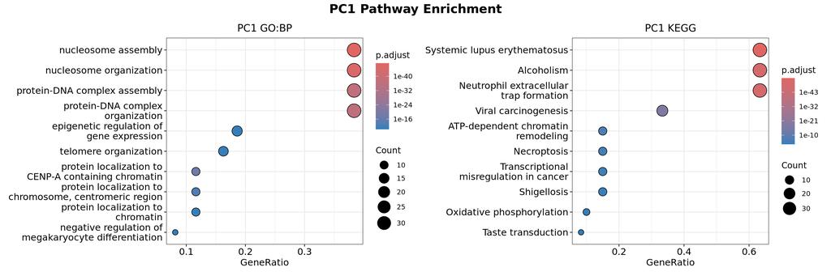

```r
# GO:BP dotplot
pc1_gobp_plot <- dotplot(pc1_go, showCategory = 10, title = "PC1 GO:BP") +
                 theme(plot.title = element_text(hjust = 0.5))

# KEGG dotplot
pc1_kegg_plot <- dotplot(pc1_kegg, showCategory = 10, title = "PC1 KEGG") +
                 theme(plot.title = element_text(hjust = 0.5))

# combine
pc1_gobp_kegg_plot <- (pc1_gobp_plot | pc1_kegg_plot) +
  plot_annotation(
    title = "PC1 Pathway Enrichment",
    theme = theme(plot.title = element_text(hjust = 0.5, size = 16, face = "bold"))
  )

pc1_gobp_kegg_plot
```

##### 3.2.5.2. Plot PC2 Enrichments

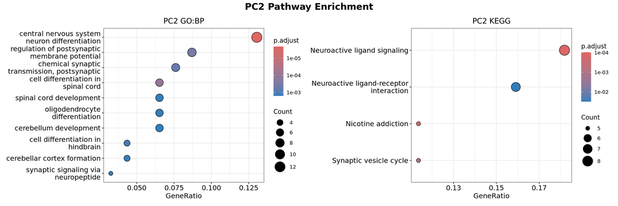

```r
# GO:BP dotplot
pc2_gobp_plot <- dotplot(pc2_go, showCategory = 10, title = "PC2 GO:BP") +
                 theme(plot.title = element_text(hjust = 0.5))

# KEGG dotplot
pc2_kegg_plot <- dotplot(pc2_kegg, showCategory = 10, title = "PC2 KEGG") +
                 theme(plot.title = element_text(hjust = 0.5))

# combine
pc2_gobp_kegg_plot <- (pc2_gobp_plot | pc2_kegg_plot) +
  plot_annotation(
    title = "PC2 Pathway Enrichment",
    theme = theme(plot.title = element_text(hjust = 0.5, size = 16, face = "bold"))
  )

pc2_gobp_kegg_plot
```

##### 3.2.5.3. Plot PC3 Enrichments

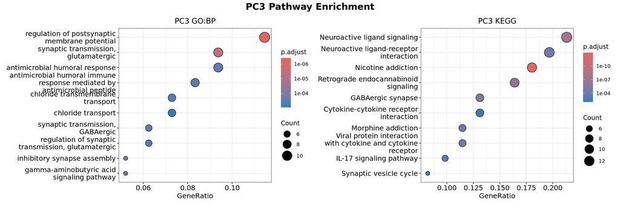

```r
# GO:BP dotplot
pc3_gobp_plot <- dotplot(pc3_go, showCategory = 10, title = "PC3 GO:BP") +
                 theme(plot.title = element_text(hjust = 0.5))

# KEGG dotplot
pc3_kegg_plot <- dotplot(pc3_kegg, showCategory = 10, title = "PC3 KEGG") +
                 theme(plot.title = element_text(hjust = 0.5))

# combine
pc3_gobp_kegg_plot <- (pc3_gobp_plot | pc3_kegg_plot) +
  plot_annotation(
    title = "PC3 Pathway Enrichment",
    theme = theme(plot.title = element_text(hjust = 0.5, size = 16, face = "bold"))
  )

pc3_gobp_kegg_plot
```

##### 3.2.5.4. Combine Enrichment Plots

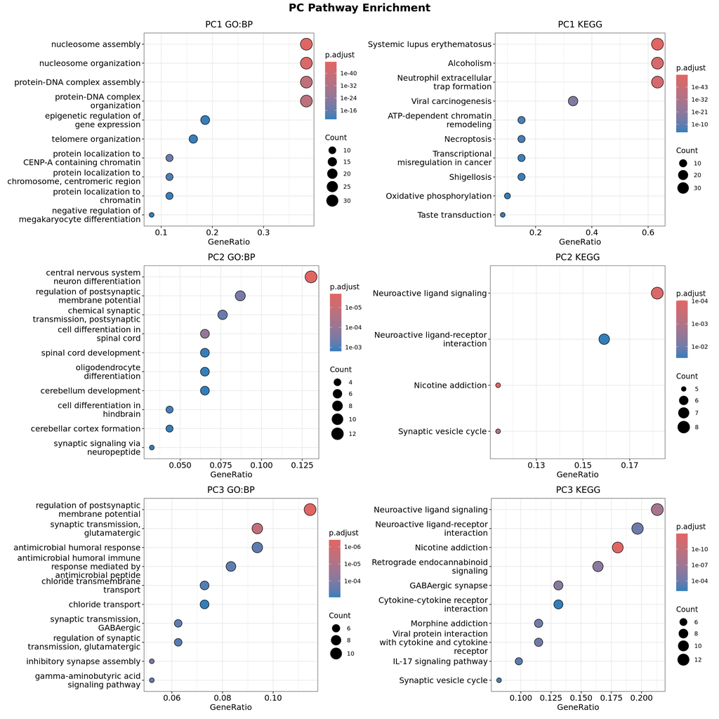

```r
pc_gobp_kegg_plot <- (pc1_gobp_kegg_plot) /
                     (pc2_gobp_kegg_plot) /
                     (pc3_gobp_kegg_plot) +

                     plot_annotation(
                       title = "PC Pathway Enrichment",
                       theme = theme(
                         plot.title = element_text(
                                        hjust = 0.5,
                                        size = 16,
                                        face = "bold"
                                      )
                         )
                     )

pc_gobp_kegg_plot
```

These plots show **dots based on confidence** backed by the **p-value significance** as well as the **proportion of the top 100 genes** loading on **each PC** that hit each pathway. The larger and redder the dot, the more reliable the enrichment signal. The most prominent dots are sufficient to deduce what each PC represents.

- **PC1**

  The most significant dots hit the following pathways:
  - **Nucleosome assembly/organisation**: **Nucleosomes** are the basic units of chromatin packaging, i.e. **DNA wrapped around histone proteins**. **High nucleosome assembly** activity indicates **active chromatin reorganization**, which occurs primarily during **cell division** when the entire genome must be duplicated and repackaged.
  - **Protein-DNA complex/organisation**: This is essentially **identical to nucleosome assembly/organization**. Both describe the physical packaging of DNA around histone proteins into chromatin.
  - **Systemic lupus erythematosus/alcoholism**: These are **not real biological signals** but KEGG artifacts. **Histone genes are annotated to these pathways** in KEGG’s database because **both conditions involve chromatin dysregulation** (i.e. disruption of the mechanisms that package DNA and control gene expression), but the connection to GBM biology is not meaningful.
  - **Neutrophil extracellular trap formation**: Neutrophils expel their **DNA and chromatin** outward to trap pathogens. Since chromatin is composed of DNA wrapped around **histone** proteins, this pathway being hit is a **consequence of histone gene presence in the loading list**, not a reflection of neutrophil biology in these tumors.

  Since **nucleosome assembly/organisation** and **histone protein presence** are both indicative of **active cell division**, PC1 is representative of **tumor proliferation rate**. Importantly, **proliferation varies independently of subtype**: both PN and ME tumors contain high and low proliferating samples, which is why the two PCA clouds **each contain mixed subtypes** rather than separating cleanly by subtype label.
- **PC2**

  The most significant dots hit the following pathways:
  - **CNS neuron differentiation**: This is indicative of the **neural stem cell transcriptomic signature** characteristic of **Proneural** GBM, i.e. tumor cells that have partially recapitulated (i.e. re-expressed) a neural differentiation program.
  - **Neuroactive ligand signaling**: **Ligands** are any molecules or ions that **bind to and trigger specific cell receptors**. **Proneural tumor** cells express **neuronal receptors** and respond to **neuroactive ligands** as part of their neural-like transcriptomic identity, consistent with the Proneural subtype’s recapitulation of neural stem cell biology.

  PC2 therefore captures **neural identity**, i.e. the **Proneural transcriptomic signature**. This explains why PC2 **partially separates the two subtypes** in the PCA plot.
- **PC3**

  PC3 represents the **mature functional end of the neural program captured by PC2**, specifically **postsynaptic membrane regulation** and **inhibitory neuron biology**, suggesting it distinguishes more neurally mature tumors within the Proneural group.

### 3.3. Plot Sample HVG Correlation Heatmap

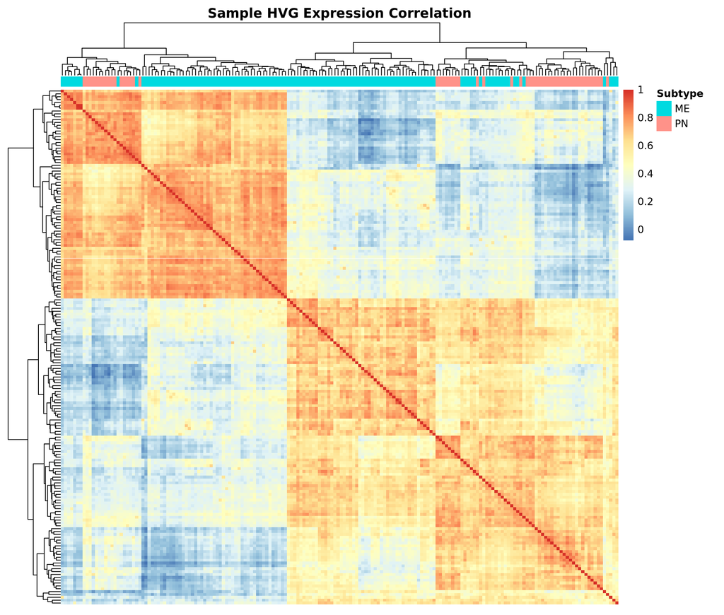

```r
# calculate sample correlation matrix using HVG expression
cor_matrix <- cor(hvg_matrix)

# annotation dataframe for subtype coloring
annot_df <- data.frame(
               Subtype   = tumor_subtype_info$paper_Transcriptome.Subtype,
               row.names = colnames(hvg_matrix)
             )

# plot heatmap
corr_plot <- pheatmap(
  cor_matrix,
  annotation_col       = annot_df,
  show_rownames        = FALSE,
  show_colnames        = FALSE,
  annotation_names_col = FALSE,
  main                 = "Sample HVG Expression Correlation",
  silent               = TRUE
)$gtable

wrap_elements(corr_plot)
```

The correlation heatmap **confirms the PCA findings**:

- **Two major clusters** of **transcriptomically similar** samples are visible **(red diagonal blocks)**, **separated** by a region of **low correlation (blue off-diagonal).** This is consistent with **PC1** capturing **tumor proliferation rate**.
- The **subtype annotation bar** imperfectly maps onto these clusters, consistent with **PC2 capturing subtype identity/differences**.

## 4. Save EDA Plots

```r
# HVG PCA plot
ggsave(
  "../03_figures/04_eda/01_hvg_pca_plot.png",
  plot = pca_plot,
  width = 8,
  height = 6,
  dpi = 300
)

# scree plot
ggsave(
  "../03_figures/04_eda/02_scree_plot.png",
  plot = scree_plot,
  width = 8,
  height = 5,
  dpi = 300
)

# combined enrichment plot
ggsave(
  "../03_figures/04_eda/03_pc_enrichment_plots.png",
  plot = pc_gobp_kegg_plot,
  width = 16,
  height = 18,
  dpi = 300
)

# sample correlation heatmap
png(                                                      # open empty graphics device
  "../03_figures/04_eda/04_sample_correlation_plot.png",  # of this filename
  width = 10,                                             # with this width
  height = 9,                                             # and this height
  units = "in",                                           # in inches
  res = 300                                               # and this dpi
)
grid::grid.draw(corr_plot)                                # draw heatmap onto graphics device
dev.off()                                                 # close graphics device
```

```r
cat("Saved 4 EDA plot files\n")
```

```
Saved 4 EDA plot files
```

## 5. Perform Sanity Checks

```r
hvg_pca_plot_exists <- file.exists("../03_figures/04_eda/01_hvg_pca_plot.png")
scree_plot_exists  <- file.exists("../03_figures/04_eda/02_scree_plot.png")
combined_enrichment_plot_exists <- file.exists("../03_figures/04_eda/03_pc_enrichment_plots.png")
sample_corr_plot_exists <- file.exists("../03_figures/04_eda/04_sample_correlation_plot.png")



# print
cat("HVG PCA plot saved:                    ", ifelse(hvg_pca_plot_exists,  "✓", "✗"), "\n")
```

```
HVG PCA plot saved:                     ✓
```

```r
cat("Scree plot saved:                      ", ifelse(scree_plot_exists, "✓", "✗"), "\n")
```

```
Scree plot saved:                       ✓
```

```r
cat("Combined enrichment plot saved:        ", ifelse(combined_enrichment_plot_exists,    "✓", "✗"), "\n")
```

```
Combined enrichment plot saved:         ✓
```

```r
cat("Sample correlation heatmap plot saved: ", ifelse(sample_corr_plot_exists, "✓", "✗"), "\n")
```

```
Sample correlation heatmap plot saved:  ✓
```

```r
# check for errors
if (all(hvg_pca_plot_exists, scree_plot_exists, combined_enrichment_plot_exists,
        sample_corr_plot_exists)) {
  cat("\nNotebook 04 complete — all outputs verified\n")
} else {
  cat("\nWARNING: One or more outputs missing\n")
}
```

```
Notebook 04 complete — all outputs verified
```